# IODS course project

Next let’s have a look at the BPRS data which contains repeated measures of 40 male subjects, divided in to two different treatment groups. A psychiatric rating scale was used to evaluate different symptoms of the subjects, values ranging from 1 to 7. It is this rating scale that is termed “BPRS”. First, let’s plot the data.

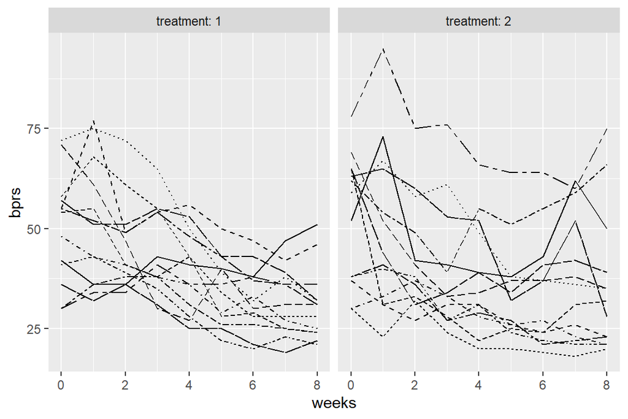

```r
ggplot(BPRS_long, aes(x = weeks, y = bprs, linetype = subject)) +
  geom_line() +
  facet_grid(. ~ treatment, labeller = label_both) +
  theme(legend.position = "none")
```

Overall, it seems that both treatments have been reducing the BPRS rating overall, perhaps treatment 1 seems to be slightly more effective at first glance. To get a better sense of what is going on, we can start out by forming a simple linear regression model of the data.

```r
# Linear regression model
lm1 <- lm(bprs ~ weeks + treatment, data = BPRS_long)

# Summary of the model
summary(lm1)
```

```
##
## Call:
## lm(formula = bprs ~ weeks + treatment, data = BPRS_long)
##
## Residuals:
##     Min      1Q  Median      3Q     Max
## -22.454  -8.965  -3.196   7.002  50.244
##
## Coefficients:
##             Estimate Std. Error t value Pr(>|t|)
## (Intercept)  46.4539     1.3670  33.982   <2e-16 ***
## weeks        -2.2704     0.2524  -8.995   <2e-16 ***
## treatment2    0.5722     1.3034   0.439    0.661
## ---
## Signif. codes:  0 '***' 0.001 '**' 0.01 '*' 0.05 '.' 0.1 ' ' 1
##
## Residual standard error: 12.37 on 357 degrees of freedom
## Multiple R-squared:  0.1851, Adjusted R-squared:  0.1806
## F-statistic: 40.55 on 2 and 357 DF,  p-value: < 2.2e-16
```

Based on the results of the linear model, there is a signicant downward trend of the BPRS rating as the weeks go on, the rating lowering by 2.27 points per week. Between the two treatments, however, there does not seem to be a significant difference, indicating that either treatment is working almost equally well. To get even greater detail, let’s perform a random intercept model on the data and see what we get.

```r
library(lme4)
RIM <- lmer(bprs ~ weeks+ treatment + (1 | subject), data = BPRS_long, REML = FALSE)

summary(RIM)
```

```
## Linear mixed model fit by maximum likelihood  ['lmerMod']
## Formula: bprs ~ weeks + treatment + (1 | subject)
##    Data: BPRS_long
##
##      AIC      BIC   logLik deviance df.resid
##   2748.7   2768.1  -1369.4   2738.7      355
##
## Scaled residuals:
##     Min      1Q  Median      3Q     Max
## -3.0481 -0.6749 -0.1361  0.4813  3.4855
##
## Random effects:
##  Groups   Name        Variance Std.Dev.
##  subject  (Intercept)  47.41    6.885
##  Residual             104.21   10.208
## Number of obs: 360, groups:  subject, 20
##
## Fixed effects:
##             Estimate Std. Error t value
## (Intercept)  46.4539     1.9090  24.334
## weeks        -2.2704     0.2084 -10.896
## treatment2    0.5722     1.0761   0.532
##
## Correlation of Fixed Effects:
##            (Intr) weeks
## weeks      -0.437
## treatment2 -0.282  0.000
```

The interpretation of the data does not change much with this model - the BPRS rating drop over the weeks of both treatments remains the same, and the treatments themselves do not seem to be significantly different from each other in producing this effect. However, we can still explore this more by doing a random intercept model and combining it with a random slope model.

```r
RIM2 <- lmer(bprs ~ weeks +treatment + (weeks| subject), data = BPRS_long, REML = FALSE)

summary(RIM2)
```

```
## Linear mixed model fit by maximum likelihood  ['lmerMod']
## Formula: bprs ~ weeks + treatment + (weeks | subject)
##    Data: BPRS_long
##
##      AIC      BIC   logLik deviance df.resid
##   2745.4   2772.6  -1365.7   2731.4      353
##
## Scaled residuals:
##     Min      1Q  Median      3Q     Max
## -2.8919 -0.6194 -0.0691  0.5531  3.7976
##
## Random effects:
##  Groups   Name        Variance Std.Dev. Corr
##  subject  (Intercept) 64.8222  8.0512
##           weeks        0.9609  0.9802   -0.51
##  Residual             97.4305  9.8707
## Number of obs: 360, groups:  subject, 20
##
## Fixed effects:
##             Estimate Std. Error t value
## (Intercept)  46.4539     2.1052  22.066
## weeks        -2.2704     0.2977  -7.626
## treatment2    0.5722     1.0405   0.550
##
## Correlation of Fixed Effects:
##            (Intr) weeks
## weeks      -0.582
## treatment2 -0.247  0.000
```

Yet still, our combined model does not change the result. In either case, it is good to test for which model fits better for the data, and for that we may do a simple ANOVA test on the two models.

```r
anova(RIM,RIM2)
```

```
## Data: BPRS_long
## Models:
## RIM: bprs ~ weeks + treatment + (1 | subject)
## RIM2: bprs ~ weeks + treatment + (weeks | subject)
##      npar    AIC    BIC  logLik deviance  Chisq Df Pr(>Chisq)
## RIM     5 2748.7 2768.1 -1369.4   2738.7
## RIM2    7 2745.4 2772.6 -1365.7   2731.4 7.2721  2    0.02636 *
## ---
## Signif. codes:  0 '***' 0.001 '**' 0.01 '*' 0.05 '.' 0.1 ' ' 1
```

Based on the results, it seems that our second model with the combined random intercept and random slope performs better. Since the latter model performed better, we shall use it to redraw our plots of the data.

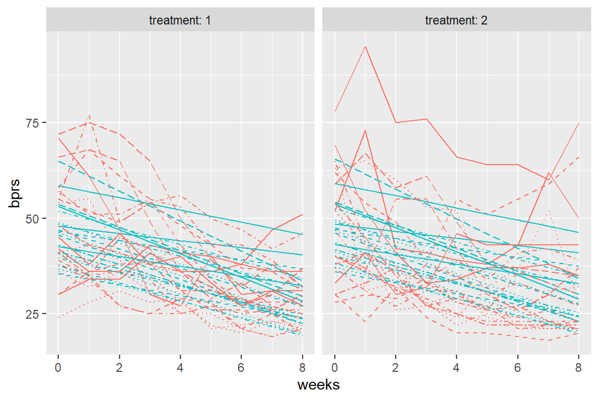

```r
BPRSL_RIM <- BPRS_long
BPRSL_RIM$bprs <- predict(RIM2)


BPRS_long$fitted <- 0
BPRSL_RIM$fitted <- 1
BPRSL_combined <- rbind(BPRS_long, BPRSL_RIM)
BPRSL_combined$fitted <- as.factor(BPRSL_combined$fitted)


ggplot(BPRSL_combined) +
  geom_line(aes(x = weeks, y = bprs, linetype = subject, col = fitted)) +
  scale_linetype_manual(values = rep(1:10, times = 4)) +
  facet_grid(. ~ treatment, labeller = label_both) +
  theme(legend.position = "none")
```